# Module 2: Basic Graph Assignment

Trey Stowe  
July 18, 2021  
BUAD 5112

```python
#Keep graphs within the Jupyter notebook
%matplotlib inline

#Import matplotlib graphing package
import matplotlib.pyplot as plt

#Import pandas package
import pandas as pd

#Import numpy package
import numpy as np
```

## Opioids in Virginia

### Question 1

Do opioid overdoses tend to be associated with less affluent areas; that is, areas where families have lower incomes?

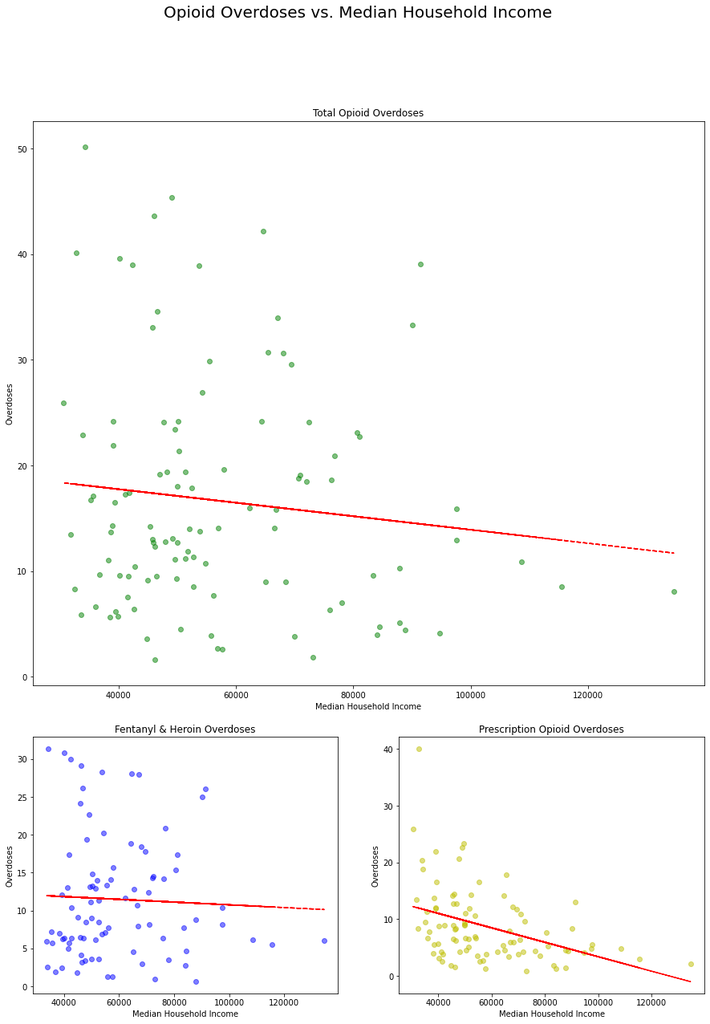

```python
#Import the OpiodsVA.csv file
df_op = pd.read_csv('OpioidsVA.csv')

#Create grid for plots
gridsize = (3, 2)

#Create subplots
fig = plt.figure(figsize = (15, 20)) #Set figure size
ax1 = plt.subplot2grid(gridsize, (0, 0), colspan = 2, rowspan = 2) #Set first graph in grid
ax2 = plt.subplot2grid(gridsize, (2, 0)) #Set second graph in grid
ax3 = plt.subplot2grid(gridsize, (2, 1)) #Set third graph in grid
fig.suptitle('Opioid Overdoses vs. Median Household Income', fontsize = 20) #Figure title

#Create scatterplots
"""A scatterplot was chosen to compare the relationship between rates of total opioid deaths and median household income;
rx opioid and fentanyl & heroin overdoses are both included as they both meet the definition of opioids."""
df1 = df_op[['MedianHouseholdIncome', 'FPOO-Rate', 'FFHO-Rate']].copy() #Create a df for both OD rates
df1 = df1[df1['FPOO-Rate'] + df1['FFHO-Rate'] > 0] #Eliminate all zero rows
ax1.scatter(df1['MedianHouseholdIncome'], df1['FPOO-Rate'] + df1['FFHO-Rate'], alpha = 0.5, c = 'g') #Scatterplot for total ODs
a, b = np.polyfit(df1['MedianHouseholdIncome'], df1["FPOO-Rate"] + df1['FFHO-Rate'], deg = 1) #Fit linear trend
est = a * df1['MedianHouseholdIncome'] + b #Linear trend line
ax1.plot(df1['MedianHouseholdIncome'], est, 'r--') #Plot trend line
ax1.set_title('Total Opioid Overdoses') #Graph title
ax1.xaxis.set_label_text('Median Household Income') #X-axis caption
ax1.yaxis.set_label_text('Overdoses') #Y-axis caption

"""A scatterplot was chosen to compare the relationship between rates of fentanyl & heroin opioid deaths and
median household income."""
df2 = df_op[['MedianHouseholdIncome', 'FFHO-Rate']].copy() #Create a df for fentanyl & heroin OD rates
df2 = df2[df2['FFHO-Rate'] > 0] #Eliminate zero rows
ax2.scatter(df2['MedianHouseholdIncome'], df2['FFHO-Rate'], alpha = 0.5, c = 'b') #Scatterplot for FHODs
a, b = np.polyfit(df2['MedianHouseholdIncome'], df2['FFHO-Rate'], deg = 1) #Fit linear trend
est = a * df2['MedianHouseholdIncome'] + b #Linear trend line
ax2.plot(df2['MedianHouseholdIncome'], est, 'r--') #Plot trend line
ax2.set_title('Fentanyl & Heroin Overdoses') #Graph title
ax2.xaxis.set_label_text('Median Household Income') #X-axis caption
ax2.yaxis.set_label_text('Overdoses') #Y-axis caption

"""A scatterplot was chosen to compare the relationship between rates of prescription opioid deaths and
median household income."""
df3 = df_op[['MedianHouseholdIncome', 'FPOO-Rate']].copy() #Create a df for rx opioid OD rates
df3 = df3[df3['FPOO-Rate'] > 0] #Eliminate zero rows
ax3.scatter(df3['MedianHouseholdIncome'], df3['FPOO-Rate'], alpha = 0.5, c = 'y') #Scatterplot for POODs
a, b = np.polyfit(df3['MedianHouseholdIncome'], df3["FPOO-Rate"], deg = 1) #Fit linear trend
est = a * df3['MedianHouseholdIncome'] + b #linear trend line
ax3.plot(df3['MedianHouseholdIncome'], est, 'r--') #Plot trend line
ax3.set_title('Prescription Opioid Overdoses') # Graph title
ax3.xaxis.set_label_text('Median Household Income') #X-axis caption
ax3.yaxis.set_label_text('Overdoses'); #Y-axis caption
```

Median household income and opioid overdoses demonstrate slight negative correlation; the effect is less pronounced for fentanyl and heroin overdoses.

### Question 2

Some people who start with `[prescription]` opioid addictions are reported to transition to heroin `[opiate/opioid]` use. What is the relationship in Virginia counties between `[prescription]` opioid overdoses and heroin `[opiate/opioid]` overdoses?

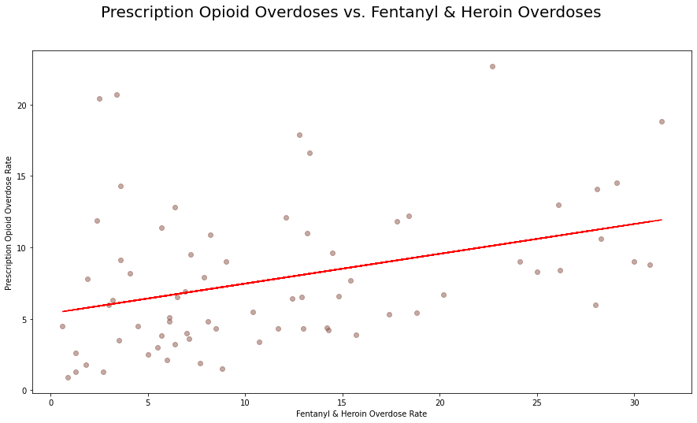

```python
#Create subplots
fig, ax = plt.subplots()
fig.suptitle('Prescription Opioid Overdoses vs. Fentanyl & Heroin Overdoses', fontsize = 20) #Figure title
fig.set_size_inches(15, 8) #Set figure size

"""A scatterplot was chosen to compare the relationship between rates of prescription opioid deaths and fentanyl
& heroin opioid deaths."""
df4 = df_op[['FFHO-Rate', 'FPOO-Rate']].copy() #Create a df for both OD rates
df4 = df4[df4['FPOO-Rate'] > 0] #Eliminate zero rows
df4 = df4[df4['FFHO-Rate'] > 0] #Eliminate zero rows
ax.scatter(df4['FFHO-Rate'], df4['FPOO-Rate'], alpha = 0.5, c = 'tab:brown') #Scatterplot for both OD rates
a, b = np.polyfit(df4['FFHO-Rate'], df4["FPOO-Rate"], deg = 1) #Fit linear trend
est = a * df4['FFHO-Rate'] + b #Linear trend line
ax.plot(df4['FFHO-Rate'], est, 'r--') #Plot trend line
ax.xaxis.set_label_text('Fentanyl & Heroin Overdose Rate') #X-axis caption
ax.yaxis.set_label_text('Prescription Opioid Overdose Rate'); #Y-axis caption
```

Postive correlation is observed between prescription opioid overdoses and overdoses of fentanyl and heroin; greater numbers of one overdose type are associated with greater numbers of the other.

## Presidents

### Question 1

Which states are associated with the greatest number of United States presidents in terms of the presidents' birthplaces?

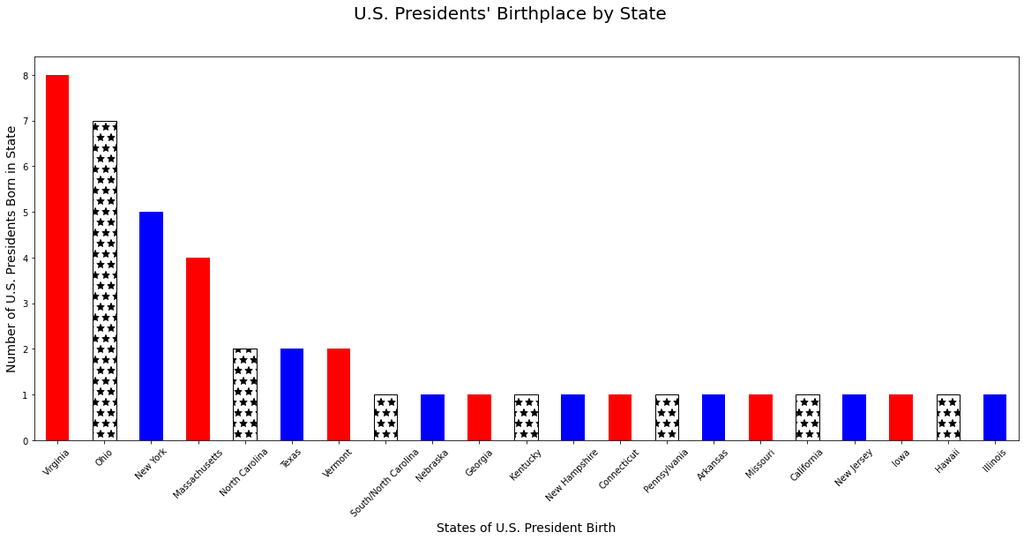

```python
#Import the presidents.csv file
df_pres = pd.read_csv('presidents.csv')

States = np.unique(df_pres['State']) #See unique state values
Count = df_pres['State'].value_counts() #Count the number of unique state values

#Create figure subplots
fig, ax = plt.subplots()
fig.set_size_inches(20, 8) #Set figure size
fig.suptitle('U.S. Presidents\' Birthplace by State', fontsize = 20) #Figure title

"""A bar plot was chosen to demonstrate the counts of each unique state by president birthplace; color and hatching employed
to make the graph a bit fun but wouldn't be used for a formal presentation."""
Count.plot.bar(edgecolor = ['none', 'black', 'none'], color = ['red', 'white', 'blue'], hatch = '*') #Bar plot of state frequency
ax.set_xticklabels(labels = Count.index, rotation = 45)
ax.yaxis.set_label_text('Number of U.S. Presidents Born in State', fontsize = 14) #X-axis caption
ax.xaxis.set_label_text('States of U.S. President Birth', fontsize = 14); #Y-axis caption
```

Virginia is the birthplace of the highest number of U.S. presidents, with eight having been born there; Ohio, New York, and Massachusetts follow with seven, five, and four, respectively.

## U.S. Monthly Auto Sales

### Question 1

How have vehicle sales in the United States varied over time?

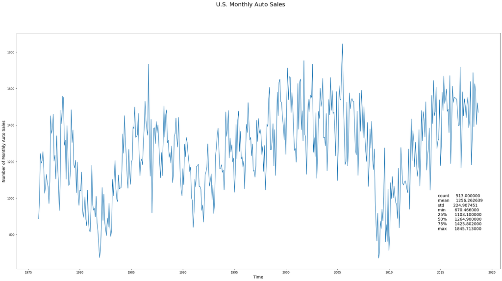

```python
#Import the TOTALNSA.csv file
df_auto = pd.read_csv('TOTALNSA.csv')
df_auto['DATE'] = pd.to_datetime(df_auto['DATE']) #Convert date to datetime

#Create figure subplots
fig, ax = plt.subplots()
fig.set_size_inches(30, 15) #Set figure size
fig.suptitle('U.S. Monthly Auto Sales', fontsize = 20) #Figure title

"""A line graph was chosen to present the data because it is a time series."""
plt.plot(df_auto['DATE'], df_auto['TOTALNSA']) #Line graph of monthly auto sales
plt.figtext(0.8, 0.25, df_auto['TOTALNSA'].describe().to_string(), fontsize = 14)
ax.yaxis.set_label_text('Number of Monthly Auto Sales', fontsize = 14) #X-axis caption
ax.xaxis.set_label_text('Time', fontsize = 14); #Y-axis caption
```

U.S. monthly auto sales have varied substantially over time (likely corresponding with macroeconomic and seasonal trends), with a minimum of 670, maximum of 1845, and standard deviation of 225.